# Functions and Automation

# Getting started

1. Clone your repo `appex05-[github_name]` to create a new project in RStudio Cloud under the STA 199 class space.
2. Configure git

   ```r
   library(usethis)
   use_git_config(user.name="your name", user.email="your email")
   ```

# Packages and Data

We’ll make use of the following packages.

```r
library(tidyverse)
library(ggpol)
```

# Tasks

## Task 1

Write a function called `center_measures` that has one argument - `x` a numeric vector. The function should return the mean and median of `x`. Below is some sample code.

```r
nums <- c(10, 5, -1, 0, 4)
c(mean(nums), median(nums))
```

```
#> [1] 3.6 4.0
```

```r
center_measures <- function() {



}
```

## Task 2

Turn the following code into a function. How many arguments does it need? What is a good name for this function?

```r
x / sum(x)
```

## Task 3

```r
congress <- read_csv("http://www2.stat.duke.edu/~sms185/data/politics/congress_long.csv")
congress
```

| year_start | year_end | party | branch | seats |
| --- | --- | --- | --- | --- |
| 1913 | 1915 | dem | house | 290 |
| 1913 | 1915 | dem | senate | 51 |
| 1913 | 1915 | gop | house | 127 |
| 1913 | 1915 | gop | senate | 44 |
| 1913 | 1915 | other | house | 18 |
| 1913 | 1915 | other | senate | 1 |
| 1913 | 1915 | vacant | house | NA |
| 1913 | 1915 | vacant | senate | NA |
| 1915 | 1917 | dem | house | 231 |
| 1915 | 1917 | dem | senate | 56 |

[output cut: 422 more lines]

Write a `for` loop to compute the number of unique values in each column of tibble `congress`. Try to stay within the `tidyverse` syntax as much as possible.

You may find function `length()` useful. Below are some examples of it in action.

```r
length(1:10)
```

```
#> [1] 10
```

```r
length(c("a", "ab", "abc", "abcd"))
```

```
#> [1] 4
```

```r
length(seq(from = 2, to = 10, by = 2))
```

```
#> [1] 5
```

## Task 4

Function `plot_congress()` is similar to the function in the slides. I added some annotation so we know the year and legislative branch.

Run the example below to see the change that was made with `annotate()`.

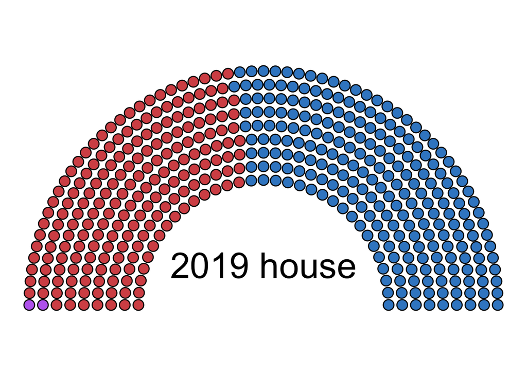

```r
plot_congress(year = 2019, leg_branch = "house")
```

Use function `plot_congress()` to create a GIF by creating plots for each year in object `congress` from 1993 to 2019. You’ll need to put your function call inside print and figure out the loop sequence. Once you are done, remove chunk option `eval=FALSE`.

```r
for () {
  print({

  })
}
```

# References

1. Grolemund, G., & Wickham, H. (2020). R for Data Science. R4ds.had.co.nz. Retrieved 9 February 2020, from https://r4ds.had.co.nz/
2. erocoar/ggpol. (2020). GitHub. Retrieved 9 February 2020, from https://github.com/erocoar/ggpol